# ILAA Tutorial: Body_fat

Jose Tamez

2023-09-21

# 1 Introduction

Iterative Linear Association Analysis (ILAA) is a computational method that creates a linear transformation from a sample of multidimensional data that effectively removes linear associations between data variables. The returned transformation matrix can be used to:

1. Do an exploratory analysis of latent variables and their association to all the observed variables
2. Do exploratory discovery of latent variables associated with an specific outcome-target
3. Addressing multicollinearity issues in linear regression models
   1. Better estimation and interpretation of model variables
   2. Improve linear model performance
4. Simplify the multidimensional search space for many ML algorithms

The objective of this tutorial is to guide users in using the ILAA to effectively accomplish the aforementioned tasks. The tutorial will showcase:

- Transform a data frame affected by data multicollinearity into a new a data frame with minimum data correlation among variables
- Visualize the transformation matrix
- Explore the returned formulas for each one of the returned latent variables
- Understand and interpret the returned latent variables
- Use ILAA as a pre-processing step to model a specific target outcome using linear models
  - Explore the model in the transformed space
  - Get the observed variables coefficients.

## 1.1 The Libraries

ILAA is a wrapper of the more general method of data decorrelation algorithm (IDeA) implemented in R and both are part of the FRESA.CAD 3.4.6 package.

```r
## From git hub
#install_github("joseTamezPena/FRESA.CAD")

library("FRESA.CAD")
```

## 1.2 Material and Methods

For this tutorial I’ll use the body-fat prediction data set. The data was downloaded from Kaggle:

https://www.kaggle.com/datasets/fedesoriano/body-fat-prediction-dataset

The Kaggle data disclaimer:

“Source The data were generously supplied by Dr. A. Garth Fisher who gave permission to freely distribute the data and use for non-commercial purposes.

Roger W. Johnson Department of Mathematics & Computer Science South Dakota School of Mines & Technology 501 East St. Joseph Street Rapid City, SD 57701

email address: rwjohnso@silver.sdsmt.edu web address: http://silver.sdsmt.edu/~rwjohnso”

## 1.3 Loading the Data

The following code loads the data and removes the density information from the data. It also computes the Body Mass Index (BMI)

```r
body_fat <- read.csv("~/GitHub/LatentBiomarkers/Data/BodyFat/BodyFat.csv", header=TRUE)

### Removing density as estimator
body_fat$Density <- NULL

body_fat$BMI <- 10000*body_fat$Weight*0.453592/((body_fat$Height*2.54)^2)
## Removing subjects with data errors
body_fat <- body_fat[body_fat$BMI<=50,]
```

## 1.4 ILAA unsupervised processing

The ILAA function is:

```r
 ILAA(data=NULL,
                thr=0.80,
                method=c("pearson","spearman"),
                Outcome=NULL,
                drivingFeatures=NULL,
                maxLoops=100,
                verbose=FALSE,
                ...)
```

where:

- `data`: The source data-frame
- *`thr`* : The target correlation goal.
- *`method`* : Defines the correlation measure
- `Outcome` The name of the target variable, and it is required for supervised learning
- `drivingFeatures` : Defines a set of variables that are aimed to be basis unaltered vectors
- `maxLoops` : The maximum number of iterations cycles
- `verbose` : Display the evolution of the algorithm.
- `…` : Parameters to be passed to the `featureAdjustment()` method

By default the ILAA function will target a correlation lower to 0.8 using the pearson correlation measure.

For this example, I’ll set the correlation goal to 0.2 in verbose mode:

```r
# Calling ILAA to achieve a final correlation of 0.2
body_fat_Decorrelated <- ILAA(body_fat,thr=0.2,verbose=TRUE)
```

fast | Included: 15 , Uni p: 0.01666667 , Outcome-Driven Size: 0 , Base Size: 1 , Rcrit: 0.134382

1 <R=0.944,thr=0.900,N= 5>, Top: 2( 1 )1 : 2 Fa= 2 : 0.900,<|>Tot Used: 5 , Added: 3 , Zero Std: 0 , Max Cor: 0.888

2 <R=0.888,thr=0.750,N= 7>, Top: 1( 5 )1 : 1 Fa= 2 : 0.750,<|>Tot Used: 9 , Added: 5 , Zero Std: 0 , Max Cor: 0.735

3 <R=0.735,thr=0.600,N= 5>, Top: 1( 4 )1 : 1 Fa= 2 : 0.600,<|>Tot Used: 13 , Added: 4 , Zero Std: 0 , Max Cor: 0.742

4 <R=0.742,thr=0.600,N= 5>, Top: 1( 1 )1 : 1 Fa= 2 : 0.600,<|>Tot Used: 13 , Added: 1 , Zero Std: 0 , Max Cor: 0.526

5 <R=0.526,thr=0.450,N= 4>, Top: 2( 2 )1 : 2 Fa= 2 : 0.450,<|>Tot Used: 15 , Added: 2 , Zero Std: 0 , Max Cor: 0.633

6 <R=0.633,thr=0.600,N= 2>, Top: 1( 1 )1 : 1 Fa= 3 : 0.600,<|>Tot Used: 15 , Added: 1 , Zero Std: 0 , Max Cor: 0.703

7 <R=0.703,thr=0.600,N= 2>, Top: 1( 1 )1 : 1 Fa= 3 : 0.600,<|>Tot Used: 15 , Added: 1 , Zero Std: 0 , Max Cor: 0.633

8 <R=0.633,thr=0.600,N= 2>, Top: 1( 1 )1 : 1 Fa= 3 : 0.600,<|>Tot Used: 15 , Added: 1 , Zero Std: 0 , Max Cor: 0.734

9 <R=0.734,thr=0.600,N= 2>, Top: 1( 1 )1 : 1 Fa= 3 : 0.600,<|>Tot Used: 15 , Added: 1 , Zero Std: 0 , Max Cor: 0.621

10 <R=0.621,thr=0.600,N= 2>, Top: 1( 1 )1 : 1 Fa= 3 : 0.600,<|>Tot Used: 15 , Added: 1 , Zero Std: 0 , Max Cor: 0.575

11 <R=0.575,thr=0.450,N= 3>, Top: 1( 1 )1 : 1 Fa= 3 : 0.450,<|>Tot Used: 15 , Added: 1 , Zero Std: 0 , Max Cor: 0.556

12 <R=0.556,thr=0.450,N= 3>, Top: 1( 1 )1 : 1 Fa= 3 : 0.450,<|>Tot Used: 15 , Added: 1 , Zero Std: 0 , Max Cor: 0.449

13 <R=0.449,thr=0.200,N= 13>, Top: 3( 3 )1 : 3 Fa= 3 : 0.200,<|>Tot Used: 15 , Added: 5 , Zero Std: 0 , Max Cor: 0.439

14 <R=0.439,thr=0.200,N= 13>, Top: 3( 5 )1 : 3 Fa= 4 : 0.200,<|>Tot Used: 15 , Added: 5 , Zero Std: 0 , Max Cor: 0.397

15 <R=0.397,thr=0.200,N= 13>, Top: 3( 5 )1 : 3 Fa= 5 : 0.200,<|>Tot Used: 15 , Added: 6 , Zero Std: 0 , Max Cor: 0.331

16 <R=0.331,thr=0.200,N= 13>, Top: 3( 1 )1 : 3 Fa= 7 : 0.200,<|>Tot Used: 15 , Added: 3 , Zero Std: 0 , Max Cor: 0.234

17 <R=0.234,thr=0.200,N= 13>, Top: 1( 1 )1 : 1 Fa= 8 : 0.200,<|>Tot Used: 15 , Added: 1 , Zero Std: 0 , Max Cor: 0.205

18 <R=0.205,thr=0.200,N= 13>, Top: 1( 1 )1 : 1 Fa= 8 : 0.200,<|>Tot Used: 15 , Added: 1 , Zero Std: 0 , Max Cor: 0.214

19 <R=0.214,thr=0.200,N= 13>, Top: 1( 1 )1 : 1 Fa= 9 : 0.200,<|>Tot Used: 15 , Added: 1 , Zero Std: 0 , Max Cor: 0.192

20 <R=0.192,thr=0.200,N= 0>

[ 20 ], 0.1921798 Decor Dimension: 15 Nused: 15 . Cor to Base: 14 , ABase: 1 , Outcome Base: 0

### 1.4.1 Data Frame Attributes

The returned data matrix contains the following attributes

```r
  attr(body_fat_Decorrelated,"UPLTM")               #The transformation matrix
  attr(body_fat_Decorrelated,"fscore")              #The score of each feature
  attr(body_fat_Decorrelated,"drivingFeatures")     #The list of driving features
  attr(body_fat_Decorrelated,"unaltered")           #The list of unaltered features
  attr(body_fat_Decorrelated,"LatentVariables")     #The list of latent variables
  attr(body_fat_Decorrelated,"R.critical")       #The estimated minium correlation
  attr(body_fat_Decorrelated,"IDeAEvolution")       #Evolution of the algorithm
```

The main attributes is “`UPLTM`”. That stores the linear transformation matrix from observed variables to the latent variable. The “`IDeAEvolution`” attribute can be used to verify if the algorithm achieved the target correlation goal, and the sparsity of the returned matrix.

### 1.4.2 Plotting the Evolution

Here we will use the `attr(dataTransformed,"IDeAEvolution")` to plot the evolution of the correlation measure and the evolution of the matrix sparsity.

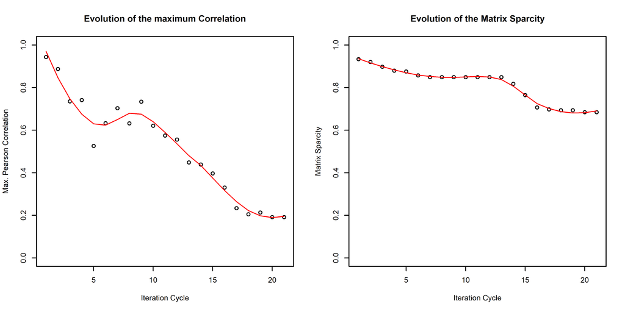

```r
par(mfrow=c(1,2),cex=0.5)

# Correlation
yval <- attr(body_fat_Decorrelated,"IDeAEvolution")$Corr
xidx <- c(1:length(yval))
plot(xidx,yval,
     xlab="Iteration Cycle",
     ylab="Max. Pearson Correlation",
     ylim=c(0,1.0),
     main="Evolution of the maximum Correlation")
  lfit <-try(loess(yval~xidx,span=0.5));
  if (!inherits(lfit,"try-error"))
  {
    plx <- try(predict(lfit,se=TRUE))
    if (!inherits(plx,"try-error"))
    {
      lines(xidx,plx$fit,lty=1,col="red")
    }
  }

# Sparsity
yval <- attr(body_fat_Decorrelated,"IDeAEvolution")$Spar

plot(xidx,yval,
     xlab="Iteration Cycle",
     ylab="Matrix Sparcity",
     ylim=c(0,1.0),
     main="Evolution of the Matrix Sparcity")
  lfit <-try(loess(yval~xidx,span=0.5));
  if (!inherits(lfit,"try-error"))
  {
    plx <- try(predict(lfit,se=TRUE))
    if (!inherits(plx,"try-error"))
    {
      lines(xidx,plx$fit,lty=1,col="red")
    }
  }
```

### 1.4.3 The ILAA transformed data

Before exploring into more detail the properties of the `ILAA` results. Let us first verify that the returned matrix does not contain features with very high correlation among them.

Here I’ll plot the original correlation and the correlation of the returned data set.

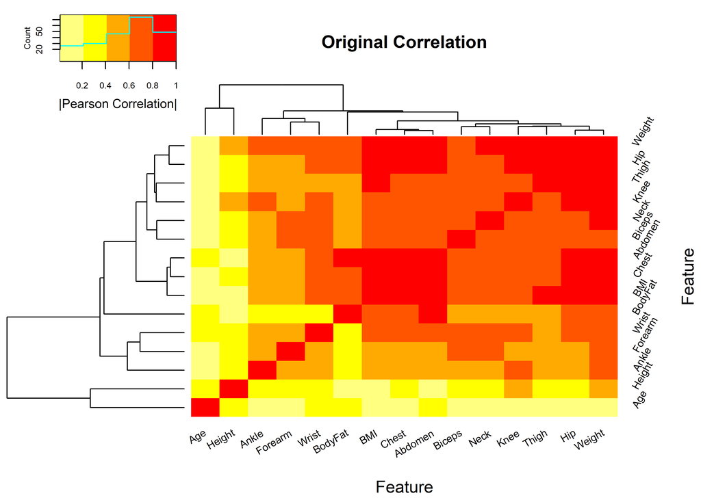

```r
# The original
  par(cex=0.6,cex.main=0.85,cex.axis=0.7)
  cormat <- cor(body_fat,method="pearson")
  gplots::heatmap.2(abs(cormat),
                    trace = "none",
                    mar = c(5,5),
                    col=rev(heat.colors(5)),
                    main = "Original Correlation",
                    cexRow = 0.75,
                    cexCol = 0.75,
                     srtCol=30,
                     srtRow=60,
                    key.title=NA,
                    key.xlab="|Pearson Correlation|",
                    xlab="Feature", ylab="Feature")
```

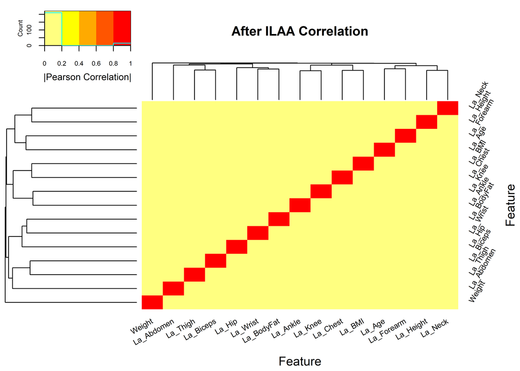

```r
# The transformed
  cormat <- cor(body_fat_Decorrelated,method="pearson")
  gplots::heatmap.2(abs(cormat),
                    trace = "none",
                    mar = c(5,5),
                    col=rev(heat.colors(5)),
                    main = "After ILAA Correlation",
                    cexRow = 0.75,
                    cexCol = 0.75,
                     srtCol=30,
                     srtRow=60,
                    key.title=NA,
                    key.xlab="|Pearson Correlation|",
                    xlab="Feature", ylab="Feature")
```

### 1.4.4 Exploring transformation

The `attr(body_fat_Decorrelated,"UPLTM")` returns the transformation matrix. The `UPLTM` is sparse, here I show a heat-map of the transformation matrix that shows which elements are different from zero.

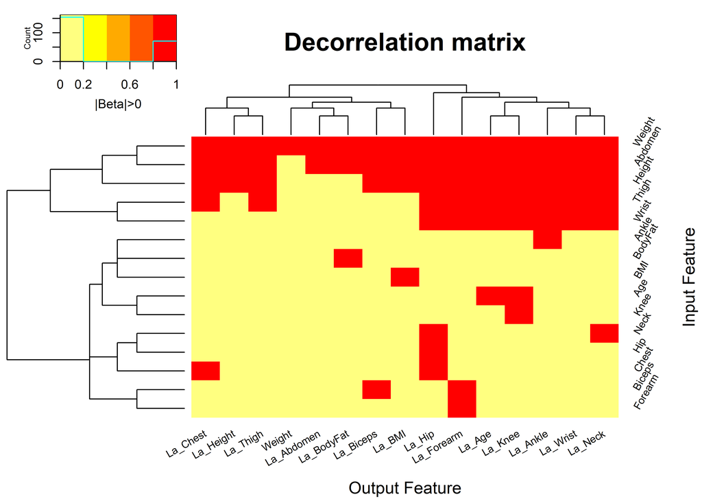

```r
  UPLTM <- attr(body_fat_Decorrelated,"UPLTM")

  gplots::heatmap.2(1.0*(abs(UPLTM)>0),
                    trace = "none",
                    mar = c(5,5),
                    col=rev(heat.colors(5)),
                    main = "Decorrelation matrix",
                    cexRow = 0.75,
                    cexCol = 0.75,
                   srtCol=30,
                   srtRow=60,
                    key.title=NA,
                    key.xlab="|Beta|>0",
                    xlab="Output Feature", ylab="Input Feature")
```

### 1.4.5 The Latent Formulas

The sparsity of the `UPLTM` matrix can be analyzed to get the formula for each on of the latent formulas. The `getLatentCoefficients()` and its attribute: `attr(LatentFormulas,"LatentCharFormulas")` can be used to display the formula of the latent variables.

```r
# Get a list with the latent formulas' coefficients
LatentFormulas <- getLatentCoefficients(body_fat_Decorrelated)

# A string character with the formulas can be obtained by:
charFormulas <- attr(LatentFormulas,"LatentCharFormulas")
pander::pander(as.matrix(charFormulas))
```

| **La_BodyFat** | + BodyFat + (0.148)Weight - (0.986)Abdomen |
| --- | --- |
| **La_Age** | + Age + (0.263)Weight + (0.569)Height - (1.181)Abdomen + (1.562)Thigh - (6.191)Wrist |
| **La_Height** | - (0.134)Weight + Height + (0.277)Abdomen |
| **La_Neck** | - (0.045)Weight - (0.014)Height + Neck - (3.82e-03)Abdomen - (0.038)Thigh - (0.721)Wrist |
| **La_Chest** | - (0.252)Weight + (0.608)Height + Chest - (0.284)Abdomen + (0.396)Thigh |
| **La_Abdomen** | - (0.325)Weight + Abdomen |
| **La_Hip** | - (0.197)Weight + (0.179)Height + (0.330)Neck + (0.174)Chest - (0.145)Abdomen + Hip - (0.347)Thigh - (0.238)Wrist |
| **La_Thigh** | - (0.203)Weight + (0.365)Height + (0.101)Abdomen + Thigh |
| **La_Knee** | - (0.029)Age - (0.037)Weight - (0.073)Height + (0.018)Abdomen - (0.199)Thigh + Knee - (0.214)Wrist |
| **La_Ankle** | - (0.043)Weight - (8.43e-03)Height + (0.066)Abdomen - (0.023)Thigh + Ankle - (0.441)Wrist |
| **La_Biceps** | - (0.115)Weight + (0.242)Height + (0.067)Abdomen + Biceps |
| **La_Forearm** | + (0.011)Weight - (0.081)Height - (0.022)Abdomen - (0.033)Thigh - (0.286)Biceps + Forearm - (0.622)Wrist |
| **La_Wrist** | - (0.034)Weight + (0.019)Height + (5.30e-03)Abdomen + (0.052)Thigh + Wrist |
| **La_BMI** | - (0.135)Weight + (0.701)Height - (0.019)Abdomen + BMI |

### 1.4.6 Latent Variable Interpretation

The ILAA returns the Unit Preserving Linear Transformation Matrix (UPLTM). This specific transformation is the combination of statistically significant linear association analysis between feature pairs. Each significant association is modeled by a linear equation; henceforth, the interpretation of each feature is as follows:

The following lines of code shows the association of the latent variable to each one of the observed parent variable, and the association of the parent variable to its linear model.

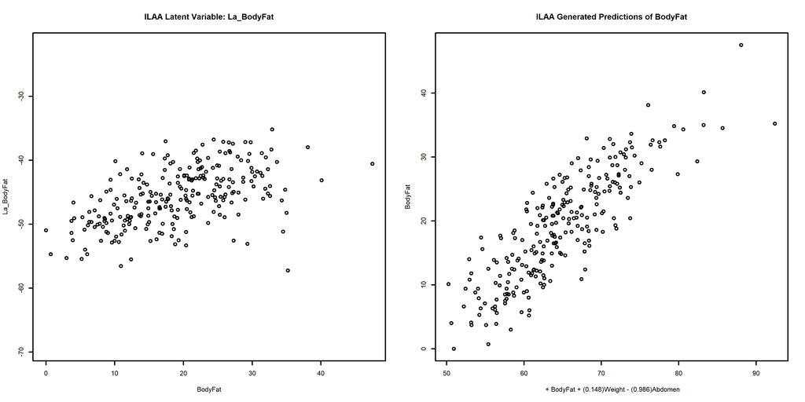

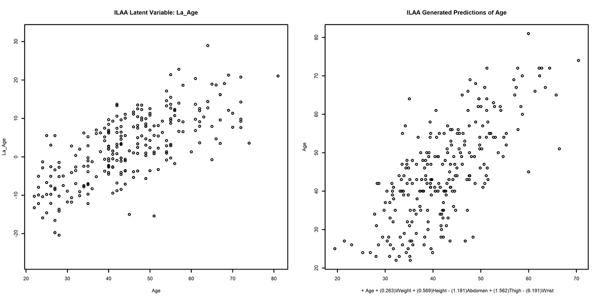

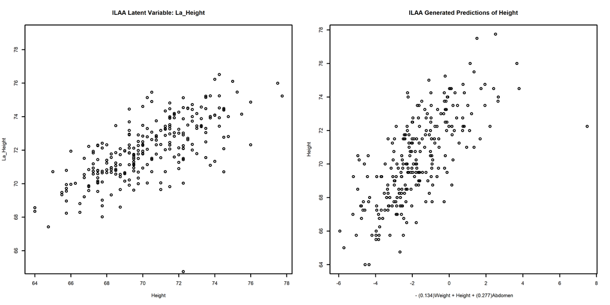

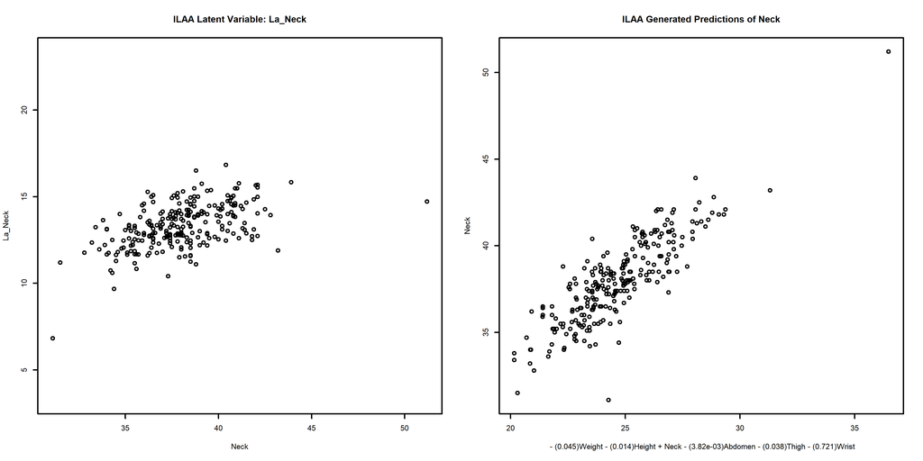

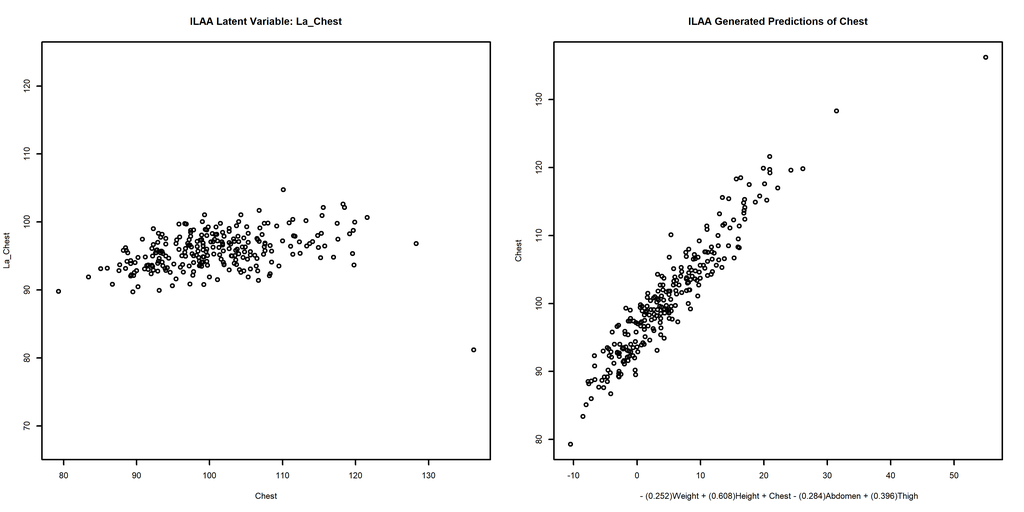

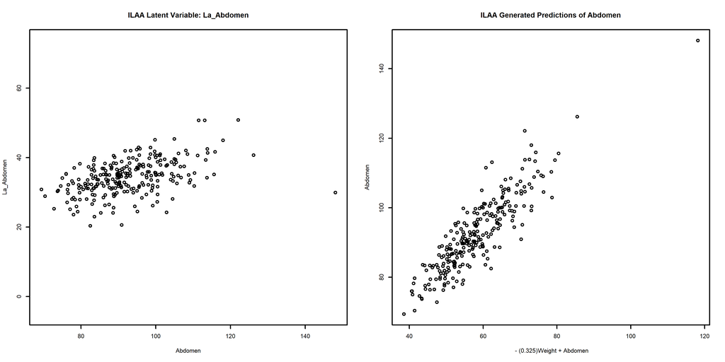

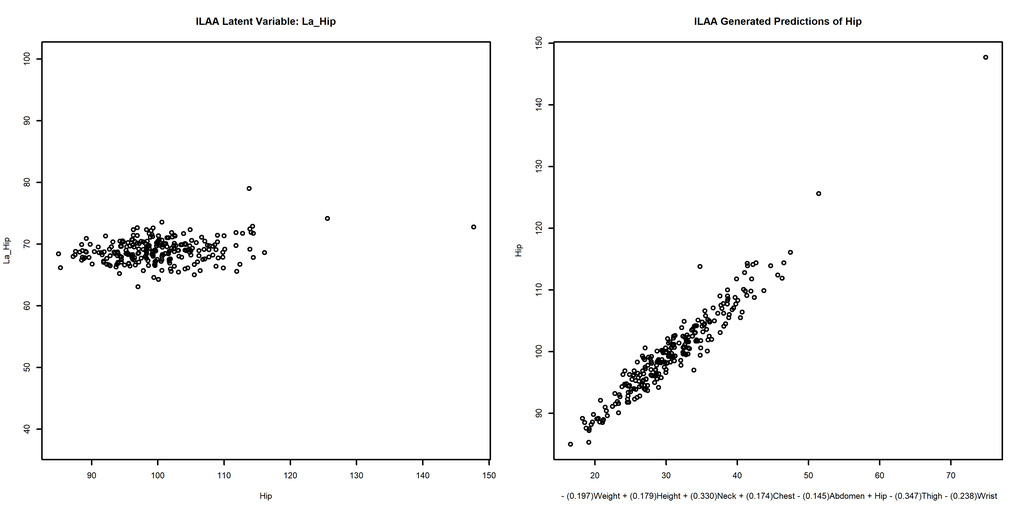

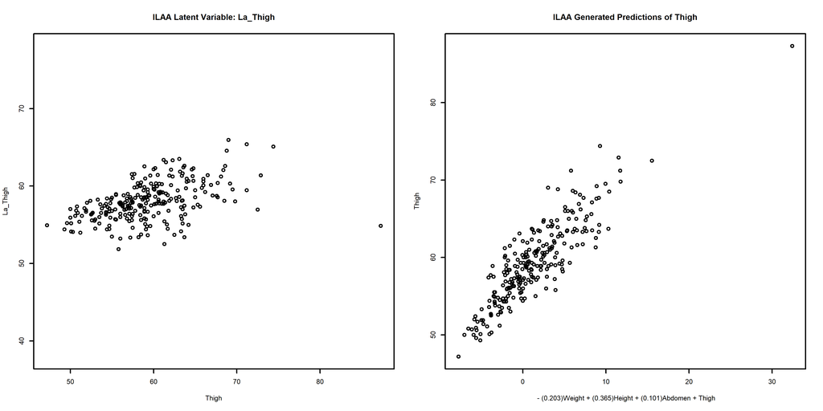

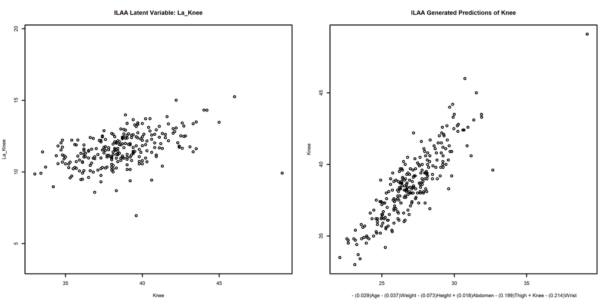

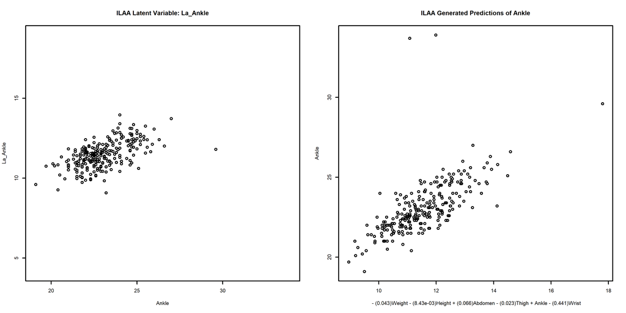

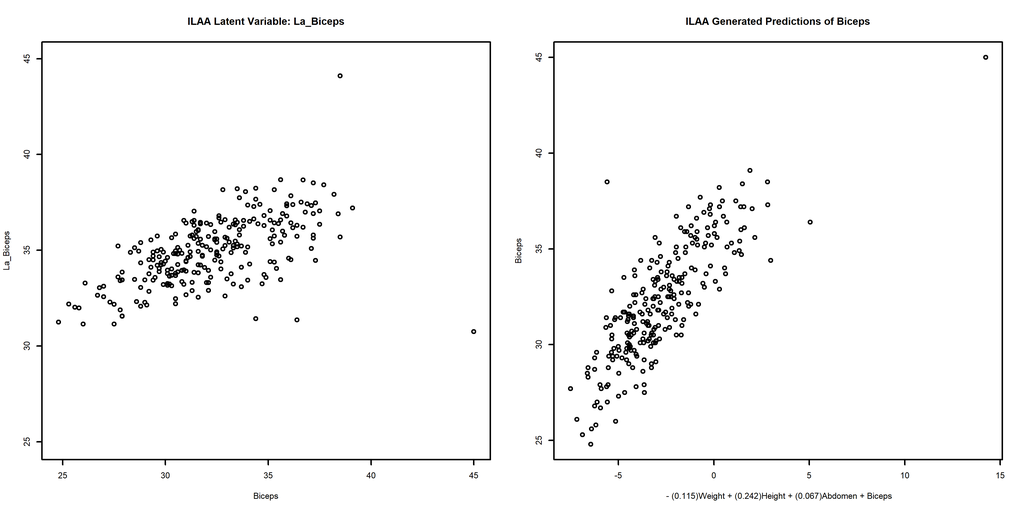

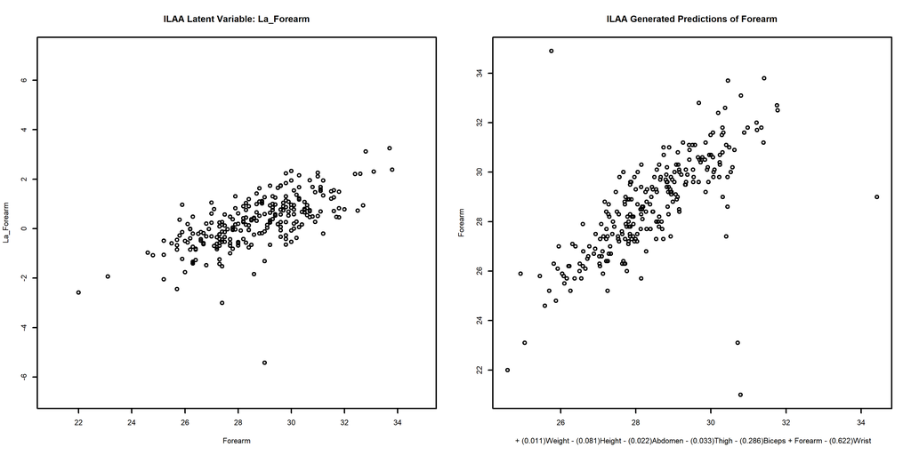

[2 more figures not shown]

```r
par(mfrow=c(1,2),cex=0.35)
fnames <- names(charFormulas)[1]
for (fnames in names(charFormulas))
{
  obsname <- str_remove(fnames,"La_")
  menv <- mean(body_fat_Decorrelated[,fnames])
  range <- max(body_fat[,obsname])-min(body_fat[,obsname])
  ylim <- c(menv-range/2,menv+range/2)
  plot(body_fat[,obsname],body_fat_Decorrelated[,fnames],
       ylim=ylim,
       ylab=fnames,
       xlab=obsname,
       main=paste("ILAA Latent Variable:",fnames))
  deformula <- LatentFormulas[[fnames]]
  noInames <- names(deformula)[names(deformula) != obsname]
  predObs <- -(as.matrix(body_fat[,noInames]) %*% deformula[noInames])
  plot(predObs,body_fat[,obsname],ylab=obsname,xlab=charFormulas[fnames],
       main=paste("ILAA Generated Predictions of",obsname),cex.labels=0.5)
}
```

```r
par(op)
```

The visual inspection of the above displayed figures shows that some latent variables are not associated with the original parent variable, but their model is fully correlated to the observed parent variable. An clear example is BMI (The last plot in the above figure).

## 1.5 ILAA for Supervised Learning

The rerecorded use of ILAA transformation in supervised learning is to split the data into training and validations sets. Henceforth, the next lines of code will split the data into training (75%) and testing (25%)

### 1.5.1 Split into Training Testing Sets

```r
# 75% for training 25% for testing
set.seed(2)
trainsamples <- sample(nrow(body_fat),3*nrow(body_fat)/4)

trainingset <- body_fat[trainsamples,]
testingset <- body_fat[-trainsamples,]
```

## 1.6 Data train analysis and prediction of the test set

The `predictDecorrelate()` function can be used to predict any new data-set from a `ILAA` transformed object. The next lines of code shows the process of transforming the training set and then use the returned object to transform the testing set.

```r
#body_fat_Decorrelated_train <- ILAA(trainingset,thr=0.2,Outcome="BodyFat",drivingFeatures="BodyFat",verbose=TRUE)
#pander::pander(attr(body_fat_Decorrelated_train,"drivingFeatures"))
body_fat_Decorrelated_train <- ILAA(trainingset,thr=0.2,Outcome="BodyFat",verbose=TRUE)
```

fast | Included: 14 , Uni p: 0.01785714 , Outcome-Driven Size: 0 , Base Size: 1 , Rcrit: 0.1532862

1 <R=0.940,thr=0.900,N= 5>, Top: 2( 1 )1 : 2 Fa= 2 : 0.900,<|>Tot Used: 5 , Added: 3 , Zero Std: 0 , Max Cor: 0.880

2 <R=0.880,thr=0.750,N= 6>, Top: 1( 5 )1 : 1 Fa= 2 : 0.750,<|>Tot Used: 9 , Added: 5 , Zero Std: 0 , Max Cor: 0.852

3 <R=0.852,thr=0.750,N= 6>, Top: 1( 1 )1 : 1 Fa= 2 : 0.750,<|>Tot Used: 10 , Added: 1 , Zero Std: 0 , Max Cor: 0.969

4 <R=0.969,thr=0.900,N= 2>, Top: 1( 1 )1 : 1 Fa= 2 : 0.900,<|>Tot Used: 10 , Added: 1 , Zero Std: 0 , Max Cor: 0.713

5 <R=0.713,thr=0.600,N= 4>, Top: 1( 3 )1 : 1 Fa= 2 : 0.600,<|>Tot Used: 13 , Added: 3 , Zero Std: 0 , Max Cor: 0.462

6 <R=0.462,thr=0.450,N= 2>, Top: 1( 1 )1 : 1 Fa= 3 : 0.450,<|>Tot Used: 13 , Added: 1 , Zero Std: 0 , Max Cor: 0.419

7 <R=0.419,thr=0.200,N= 13>, Top: 1( 1 )1 : 1 Fa= 3 : 0.200,<|>Tot Used: 13 , Added: 1 , Zero Std: 0 , Max Cor: 0.430

8 <R=0.430,thr=0.200,N= 13>, Top: 1( 3 )1 : 1 Fa= 3 : 0.200,<|>Tot Used: 13 , Added: 3 , Zero Std: 0 , Max Cor: 0.394

9 <R=0.394,thr=0.200,N= 13>, Top: 1( 2 )1 : 1 Fa= 3 : 0.200,<|>Tot Used: 14 , Added: 2 , Zero Std: 0 , Max Cor: 0.413

10 <R=0.413,thr=0.200,N= 13>, Top: 1( 3 )1 : 1 Fa= 4 : 0.200,<|>Tot Used: 14 , Added: 3 , Zero Std: 0 , Max Cor: 0.394

11 <R=0.394,thr=0.200,N= 13>, Top: 1( 1 )1 : 1 Fa= 4 : 0.200,<|>Tot Used: 14 , Added: 1 , Zero Std: 0 , Max Cor: 0.394

12 <R=0.394,thr=0.200,N= 13>, Top: 1( 5 )1 : 1 Fa= 5 : 0.200,<|>Tot Used: 14 , Added: 5 , Zero Std: 0 , Max Cor: 0.365

13 <R=0.365,thr=0.200,N= 13>, Top: 2( 2 )1 : 2 Fa= 7 : 0.200,<|>Tot Used: 14 , Added: 5 , Zero Std: 0 , Max Cor: 0.243

14 <R=0.243,thr=0.200,N= 13>, Top: 1( 2 )1 : 1 Fa= 8 : 0.200,<|>Tot Used: 14 , Added: 2 , Zero Std: 0 , Max Cor: 0.204

15 <R=0.204,thr=0.200,N= 13>, Top: 1( 1 )1 : 1 Fa= 8 : 0.200,<|>Tot Used: 14 , Added: 1 , Zero Std: 0 , Max Cor: 0.199

16 <R=0.199,thr=0.200,N= 0>

[ 16 ], 0.1988026 Decor Dimension: 14 Nused: 14 . Cor to Base: 13 , ABase: 1 , Outcome Base: 0

```r
#pander::pander(attr(body_fat_Decorrelated_train,"drivingFeatures"))
body_fat_Decorrelated_test <- predictDecorrelate(body_fat_Decorrelated_train,testingset)
```

### 1.6.1 Train a regression model for body fat prediction

Once we have a transformed training and testing set, we can proceed to train a linear model of the body fat content. For this example we will use the `LASSO_1SE()` function of the FRESA.CAD package to model the $BodyFat$ using all the variables in the transformed training set.

```r
modelBodyFat <- LASSO_1SE(BodyFat~.,body_fat_Decorrelated_train)
pander::pander(as.matrix(modelBodyFat$coef))
```

| **(Intercept)** | -33.5987 |
| --- | --- |
| **La_Age** | 0.0487 |
| **Weight** | 0.1587 |
| **La_Chest** | -0.0413 |
| **La_Abdomen** | 0.7616 |
| **La_Wrist** | -1.6268 |
| **La_BMI** | 1.7145 |

The last lines of code display the beta coefficients of the model.

### 1.6.2 The Model Coefficients in the Observed Space

The FRESA.CAD package provides a handy function, `getObservedCoef()`m to get the linear beta coefficients from the transformed object. The next next lines of codes shows the procedure.

```r
# Get the coefficients in the observed space
observedCoef <- getObservedCoef(body_fat_Decorrelated_train,modelBodyFat)
pander::pander(as.matrix(observedCoef$coefficients))
```

| **(Intercept)** | -33.59871 |
| --- | --- |
| **Age** | -0.03848 |
| **Weight** | -0.10673 |
| **Chest** | -0.00558 |
| **Abdomen** | 0.76163 |
| **Biceps** | 0.29132 |
| **Wrist** | -0.45232 |
| **BMI** | 0.09781 |

### 1.6.3 Predict Using the Transformed Data-Set

The user can predict the BodyFat content using the handy `predict()` function. After that we can measure the testing performance using the `predictionStats_regression()` function.

```r
predicBodyFat <- predict(modelBodyFat,body_fat_Decorrelated_test)
rmetrics <- predictionStats_regression(cbind(testingset$BodyFat,predicBodyFat),"Body Fat")
```

Body Fat

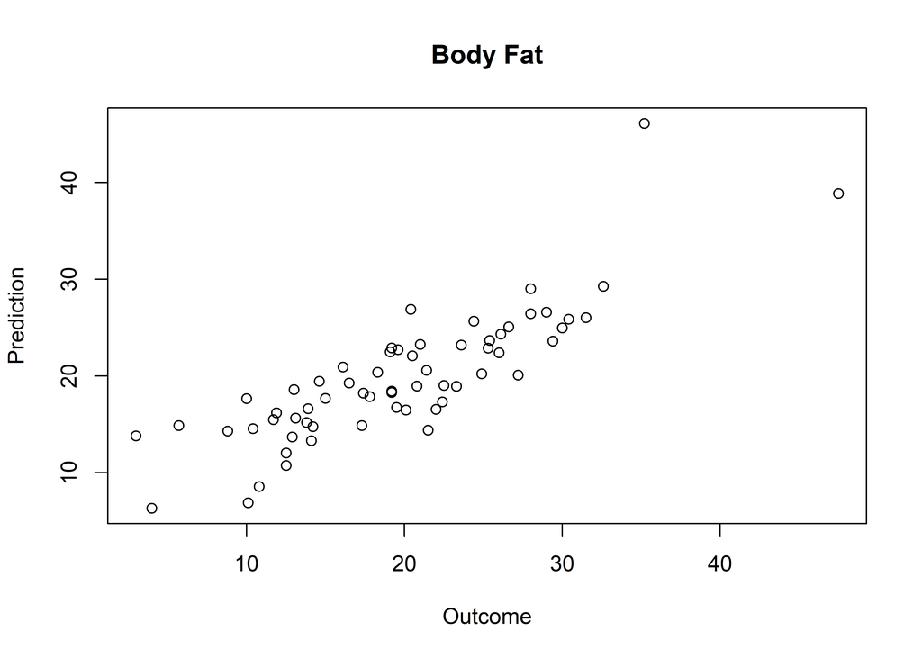

```r
pander::pander(rmetrics)
```

- **corci**:

  | cor |  |  |
  | --- | --- | --- |
  | 0.843 | 0.752 | 0.902 |

- **biasci**: *0.094*, *-0.986* and *1.174*
- **RMSEci**: *4.29*, *3.65* and *5.19*
- **spearmanci**:

  | 50% | 2.5% | 97.5% |
  | --- | --- | --- |
  | 0.839 | 0.731 | 0.909 |

- **MAEci**:

  | 50% | 2.5% | 97.5% |
  | --- | --- | --- |
  | 3.49 | 2.92 | 4.11 |

- **pearson**:

  Pearson’s product-moment correlation: `predictions[, 1]` and `predictions[, 2]`

  | Test statistic | df | P value | Alternative hypothesis | cor |
  | --- | --- | --- | --- | --- |
  | 12.2 | 61 | 4.79e-18 * * * | two.sided | 0.843 |

### 1.6.4 Prediction Using the Observed Features

An ILAA user has the option to predict the $BodyFat$ content from the observed testing set using the computed beta coefficients. The next lines of code show how to do the prediction using `model.matrix()` R function and the dot product `%*%` :

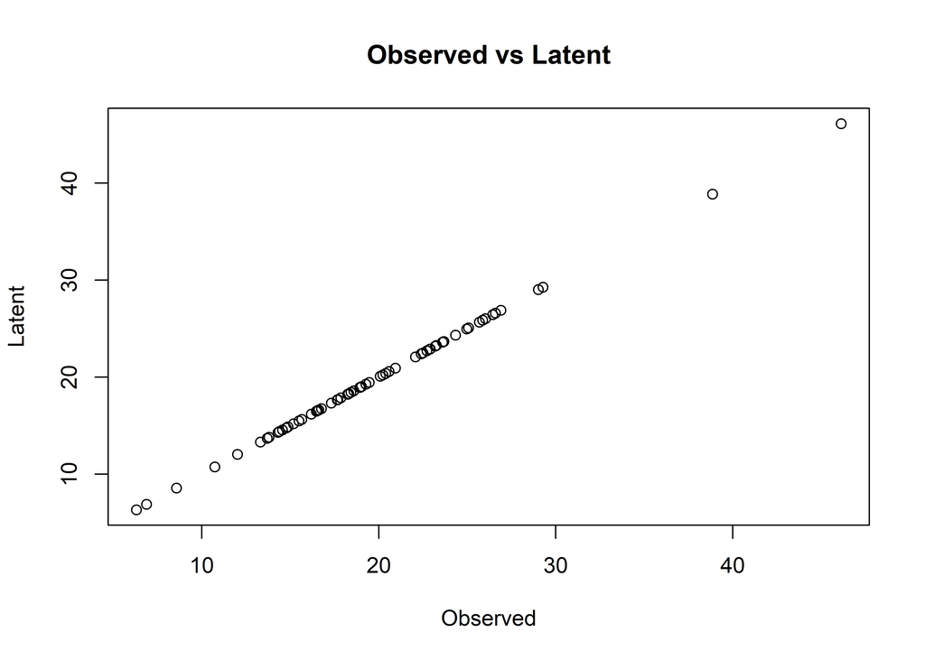

```r
predicBodyFatObst <- model.matrix(formula(observedCoef$formula),testingset) %*% observedCoef$coefficients

plot(predicBodyFatObst,predicBodyFat,xlab="Observed",ylab="Latent",main="Observed vs Latent")
```

The last plot shows the expected result: that both predictions are identical.

### 1.6.5 Comparison to Raw Model

A last experiment is to compare the differences between a LASSO model created from the observed features to the model created from the transformed observations.

The next lines of code compute the linear model using LASSO from the original observed data. Then, it computes the predicted performance.

```r
rawmodelBodyFat <- LASSO_1SE(BodyFat~.,trainingset)
pander::pander(rawmodelBodyFat$coef)
```

| (Intercept) | Height | Abdomen | Wrist |
| --- | --- | --- | --- |
| -15.4 | -0.325 | 0.643 | -0.115 |

```r
rawpredicBodyFat <- predict(rawmodelBodyFat,testingset)
rmetrics <- predictionStats_regression(cbind(testingset$BodyFat,rawpredicBodyFat),"Body Fat")
```

Body Fat

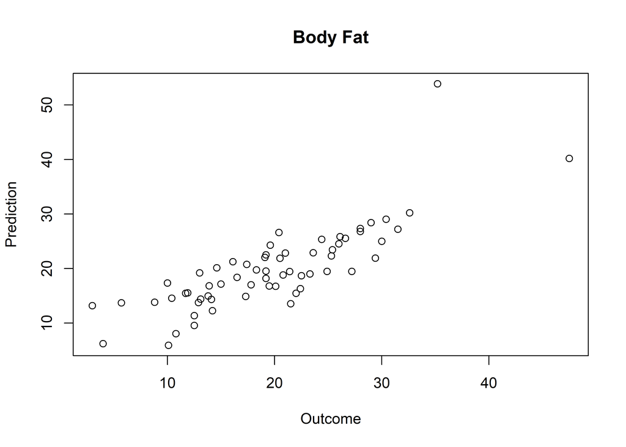

```r
pander::pander(rmetrics)
```

- **corci**:

  | cor |  |  |
  | --- | --- | --- |
  | 0.817 | 0.714 | 0.886 |

- **biasci**: *0.159*, *-1.019* and *1.337*
- **RMSEci**: *4.68*, *3.99* and *5.67*
- **spearmanci**:

  | 50% | 2.5% | 97.5% |
  | --- | --- | --- |
  | 0.819 | 0.692 | 0.898 |

- **MAEci**:

  | 50% | 2.5% | 97.5% |
  | --- | --- | --- |
  | 3.55 | 2.86 | 4.38 |

- **pearson**:

  Pearson’s product-moment correlation: `predictions[, 1]` and `predictions[, 2]`

  | Test statistic | df | P value | Alternative hypothesis | cor |
  | --- | --- | --- | --- | --- |
  | 11.1 | 61 | 3.01e-16 * * * | two.sided | 0.817 |

### 1.6.6 Comparing the Feature Significance on the Models

The main advantage of the ILAA transformation is that the returned latent variables are not collinear hence the statistically significance of the beta coefficients are not affected by multiculturalism. The next lines of code shows how to get the beta coefficients using the `lm()` , and `summary.lm()` functions.

The inspection of the summary results clearly shows that all the beta coefficients on the transformed data set are significant while only three coefficients from the observed data set are statistically significant.

```r
par(mfrow=c(2,2),cex=0.5)

rawlm <- lm(BodyFat~.,trainingset[,c("BodyFat",names(rawmodelBodyFat$coef)[-1])])
pander::pander(rawlm,add.significance.stars=TRUE)
```

Fitting linear model: BodyFat ~ .

|  | Estimate | Std. Error | t value | Pr(>\|t\|) |  |
| --- | --- | --- | --- | --- | --- |
| **(Intercept)** | 6.409 | 9.7424 | 0.658 | 5.11e-01 |  |
| **Height** | -0.456 | 0.1360 | -3.355 | 9.65e-04 | * * * |
| **Abdomen** | 0.772 | 0.0405 | 19.069 | 1.91e-45 | * * * |
| **Wrist** | -1.457 | 0.4850 | -3.005 | 3.02e-03 | * * |

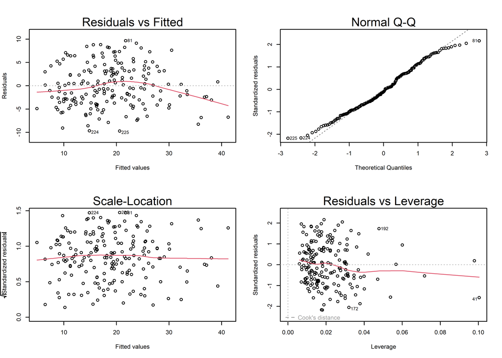

```r
plot(rawlm)
```

```r
par(mfrow=c(2,2),cex=0.5)
Delm <- lm(BodyFat~.,body_fat_Decorrelated_train[,c("BodyFat",names(modelBodyFat$coef)[-1])])
pander::pander(Delm,add.significance.stars=TRUE)
```

Fitting linear model: BodyFat ~ .

|  | Estimate | Std. Error | t value | Pr(>\|t\|) |  |
| --- | --- | --- | --- | --- | --- |
| **(Intercept)** | -20.491 | 10.3563 | -1.98 | 4.94e-02 | * |
| **La_Age** | 0.121 | 0.0275 | 4.38 | 1.97e-05 | * * * |
| **Weight** | 0.183 | 0.0118 | 15.53 | 3.98e-35 | * * * |
| **La_Chest** | -0.298 | 0.1059 | -2.81 | 5.48e-03 | * * |
| **La_Abdomen** | 0.928 | 0.1077 | 8.61 | 3.47e-15 | * * * |
| **La_Wrist** | -2.983 | 0.5556 | -5.37 | 2.40e-07 | * * * |
| **La_BMI** | 2.189 | 0.2208 | 9.91 | 8.88e-19 | * * * |

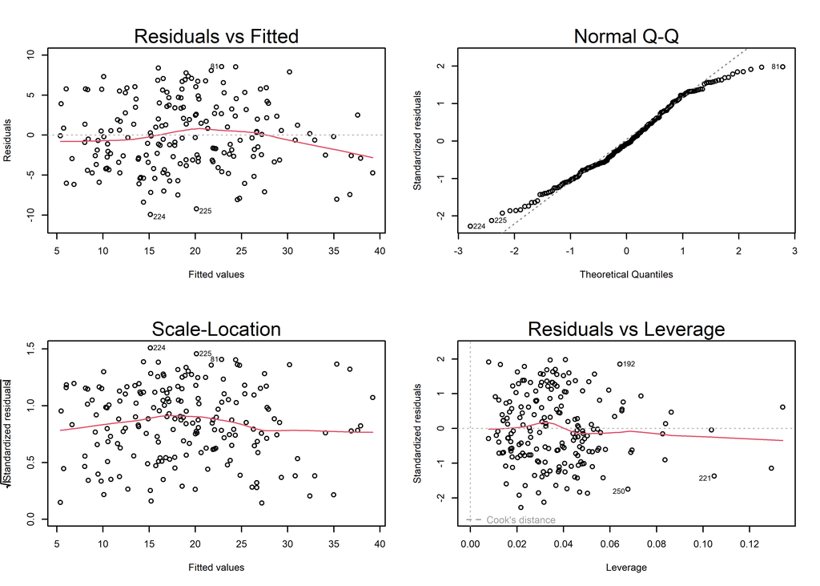

```r
plot(Delm)
```

```r
par(op)
```